# Banu Boopalan: Module1 Homework

**Principles of Data Visualization and Introduction to ggplot2**

I have provided you with data about the 5,000 fastest growing companies in the US, as compiled by Inc. magazine. lets read this in:

```r
inc <- read.csv("https://raw.githubusercontent.com/charleyferrari/CUNY_DATA_608/master/module1/Data/inc5000_data.csv", header= TRUE)
```

And lets preview this data:

```r
head(inc)
```

|  | Rank | Name | Growth_Rate | Revenue | Industry | Employees | City | State |
| --- | --- | --- | --- | --- | --- | --- | --- | --- |
| 1 | 1 | Fuhu | 421.48 | 1.179e+08 | Consumer Products & Services | 104 | El Segundo | CA |
| 2 | 2 | FederalConference.com | 248.31 | 4.960e+07 | Government Services | 51 | Dumfries | VA |
| 3 | 3 | The HCI Group | 245.45 | 2.550e+07 | Health | 132 | Jacksonville | FL |
| 4 | 4 | Bridger | 233.08 | 1.900e+09 | Energy | 50 | Addison | TX |
| 5 | 5 | DataXu | 213.37 | 8.700e+07 | Advertising & Marketing | 220 | Boston | MA |
| 6 | 6 | MileStone Community Builders | 179.38 | 4.570e+07 | Real Estate | 63 | Austin | TX |

```r
NA
```

```r
summary(inc)
```

```
      Rank          Name            Growth_Rate         Revenue            Industry
 Min.   :   1   Length:5001        Min.   :  0.340   Min.   :2.000e+06   Length:5001
 1st Qu.:1252   Class :character   1st Qu.:  0.770   1st Qu.:5.100e+06   Class :character
 Median :2502   Mode  :character   Median :  1.420   Median :1.090e+07   Mode  :character
 Mean   :2502                      Mean   :  4.612   Mean   :4.822e+07
 3rd Qu.:3751                      3rd Qu.:  3.290   3rd Qu.:2.860e+07
 Max.   :5000                      Max.   :421.480   Max.   :1.010e+10

   Employees           City              State
 Min.   :    1.0   Length:5001        Length:5001
 1st Qu.:   25.0   Class :character   Class :character
 Median :   53.0   Mode  :character   Mode  :character
 Mean   :  232.7
 3rd Qu.:  132.0
 Max.   :66803.0
 NA's   :12
```

Think a bit on what these summaries mean. Use the space below to add some more relevant non-visual exploratory information you think helps you understand this data:

##Answer tried to understand by summarizing to understand he data.

```r
#Top 50 records by revenue
```

```
There were 50 or more warnings (use warnings() to see the first 50)
```

```r
revenuetop50 = inc %>% arrange(desc(Revenue)) %>% head(50)
#revenuetop50
revenuetop50$Revenue1 = sapply(revenuetop50$Revenue, function(x) paste(round((x / 1e9), 1), " Billion"))
revenuetop50 %>% kable() %>% kable_styling()
```

| Rank | Name | Growth_Rate | Revenue | Industry | Employees | City | State | Revenue1 |
| --- | --- | --- | --- | --- | --- | --- | --- | --- |
| 4788 | CDW | 0.41 | 1.010e+10 | Computer Hardware | 6800 | Vernon Hills | IL | 10.1 Billion |
| 3853 | ABC Supply | 0.73 | 4.700e+09 | Construction | 6549 | Beloit | WI | 4.7 Billion |
| 4936 | Coty | 0.36 | 4.600e+09 | Consumer Products & Services | 10000 | New York | NY | 4.6 Billion |
| 4997 | Dot Foods | 0.34 | 4.500e+09 | Food & Beverage | 3919 | Mt. Sterling | IL | 4.5 Billion |
| 4716 | Westcon Group | 0.44 | 3.800e+09 | IT Services | 3000 | Tarrytown | NY | 3.8 Billion |
| 4246 | American Tire Distributors | 0.59 | 3.500e+09 | Consumer Products & Services | 3341 | Huntersville | NC | 3.5 Billion |
| 4052 | Kum & Go | 0.65 | 2.800e+09 | Retail | 4589 | West Des Moines | IA | 2.8 Billion |
| 4802 | Boise Cascade | 0.41 | 2.800e+09 | Construction | 4470 | Boise | ID | 2.8 Billion |
| 1397 | EnvisionRxOptions | 2.88 | 2.700e+09 | Health | 625 | Twinsburg | OH | 2.7 Billion |
| 2522 | DLA Piper | 1.41 | 2.400e+09 | Business Products & Services | 4036 | Chicago | IL | 2.4 Billion |
| 4629 | Prime Therapeutics | 0.47 | 2.000e+09 | Health | 2549 | Eagan | MN | 2 Billion |
| 4 | Bridger | 233.08 | 1.900e+09 | Energy | 50 | Addison | TX | 1.9 Billion |
| 1843 | Sun Coast Resources | 2.08 | 1.900e+09 | Energy | 1640 | Houston | TX | 1.9 Billion |
| 3844 | Atlas Oil Company | 0.74 | 1.900e+09 | Logistics & Transportation | 374 | Taylor | MI | 1.9 Billion |
| 4961 | Kirkland & Ellis | 0.36 | 1.900e+09 | Business Products & Services | 1517 | Chicago | IL | 1.9 Billion |
| 1488 | Sprouts Farmers Market | 2.68 | 1.800e+09 | Consumer Products & Services | 13200 | Phoenix | AZ | 1.8 Billion |
| 4689 | Global Brass and Copper Holdings | 0.45 | 1.700e+09 | Manufacturing | 1986 | Schaumburg | IL | 1.7 Billion |
| 3463 | Hogan Lovells | 0.89 | 1.600e+09 | Business Products & Services | 2280 | Washington | DC | 1.6 Billion |
| 2145 | AdvancePierre Foods | 1.73 | 1.500e+09 | Food & Beverage | 4000 | Cincinnati | OH | 1.5 Billion |
| 3650 | Genco | 0.82 | 1.500e+09 | Logistics & Transportation | 10800 | Pittsburgh | PA | 1.5 Billion |
| 960 | Advanced Disposal | 4.51 | 1.400e+09 | Environmental Services | 5347 | Ponte Vedra | FL | 1.4 Billion |
| 2236 | Total Quality Logistics | 1.65 | 1.400e+09 | Logistics & Transportation | 2116 | Cincinnati | OH | 1.4 Billion |
| 2496 | Carahsoft Technology | 1.42 | 1.400e+09 | Government Services | 365 | Reston | VA | 1.4 Billion |
| 3414 | Restoration Hardware | 0.91 | 1.200e+09 | Retail | 2900 | Corte Madera | CA | 1.2 Billion |
| 1908 | Diplomat Specialty Pharmacy | 1.99 | 1.100e+09 | Health | 761 | Flint | MI | 1.1 Billion |
| 3734 | KSS | 0.78 | 1.000e+09 | Manufacturing | 8500 | Sterling Heights | MI | 1 Billion |
| 3425 | Blackhawk Network Holdings | 0.90 | 9.591e+08 | Financial Services | 725 | Pleasanton | CA | 1 Billion |
| 1996 | Ambit Energy | 1.88 | 9.303e+08 | Energy | 492 | Dallas | TX | 0.9 Billion |
| 4532 | GoDaddy.com | 0.49 | 9.109e+08 | IT Services | 3369 | Scottsdale | AZ | 0.9 Billion |
| 2958 | ImmixGroup | 1.15 | 8.836e+08 | IT Services | 252 | McLean | VA | 0.9 Billion |
| 4793 | LORD Corporation | 0.41 | 8.615e+08 | Manufacturing | 2959 | Cary | NC | 0.9 Billion |
| 3163 | Quinn Emanuel | 1.03 | 8.525e+08 | Business Products & Services | 697 | Los Angeles | CA | 0.9 Billion |
| 2961 | Genesis-ATC | 1.15 | 8.462e+08 | Telecommunications | 347 | San Antonio | TX | 0.8 Billion |
| 1284 | Hearthside Food Solutions | 3.17 | 8.396e+08 | Food & Beverage | 5000 | Downers Grove | IL | 0.8 Billion |
| 1480 | Coyote Logistics | 2.70 | 7.864e+08 | Logistics & Transportation | 1219 | Chicago | IL | 0.8 Billion |
| 4765 | Squire Sanders | 0.42 | 7.745e+08 | Business Products & Services | 1257 | Cleveland | OH | 0.8 Billion |
| 3921 | Granite Telecommunications | 0.70 | 7.362e+08 | Telecommunications | 1000 | Quincy | MA | 0.7 Billion |
| 4854 | Arnold & Porter | 0.40 | 7.310e+08 | Business Products & Services | 748 | Washington | DC | 0.7 Billion |
| 1869 | Universal Services of America | 2.04 | 7.181e+08 | Security | 20000 | Santa Ana | CA | 0.7 Billion |
| 2274 | Liberty Power | 1.61 | 7.108e+08 | Energy | 277 | Fort Lauderdale | FL | 0.7 Billion |
| 4427 | Sunshine Minting | 0.53 | 7.061e+08 | Manufacturing | 280 | Coeur D' Alene | ID | 0.7 Billion |
| 4459 | Belcan | 0.52 | 6.887e+08 | Engineering | 10000 | Cincinnati | OH | 0.7 Billion |
| 2806 | Goodman Networks | 1.23 | 6.509e+08 | Telecommunications | 1693 | Plano | TX | 0.7 Billion |
| 4009 | Schumacher Group | 0.67 | 6.130e+08 | Health | 1945 | Lafayette | LA | 0.6 Billion |
| 4815 | Perkins Coie | 0.40 | 6.080e+08 | Business Products & Services | 823 | Seattle | WA | 0.6 Billion |
| 1768 | The Cellular Connection | 2.17 | 6.065e+08 | Telecommunications | 1428 | Marion | IN | 0.6 Billion |
| 2537 | Wayfair.com | 1.40 | 6.020e+08 | Retail | 1300 | Boston | MA | 0.6 Billion |
| 4577 | Sutherland Global Services | 0.48 | 5.976e+08 | Business Products & Services | 32000 | Pittsford | NY | 0.6 Billion |
| 4093 | Advanced BioEnergy | 0.64 | 5.848e+08 | Energy | 75 | Bloomington | MN | 0.6 Billion |
| 4857 | AVI-SPL | 0.39 | 5.807e+08 | Business Products & Services | 1800 | Tampa | FL | 0.6 Billion |

```r
NA
```

## Question 1

Create a graph that shows the distribution of companies in the dataset by State (ie how many are in each state). There are a lot of States, so consider which axis you should use. This visualization is ultimately going to be consumed on a ‘portrait’ oriented screen (ie taller than wide), which should further guide your layout choices.

## Answer 1

I used ggplot below to show a portrait graph by using coord_flip().Then using Theme_Tufte. Additionally then I tried to plot the numbers on the bar graph and adjusted to size 3 so I can show the numbers on the graph.

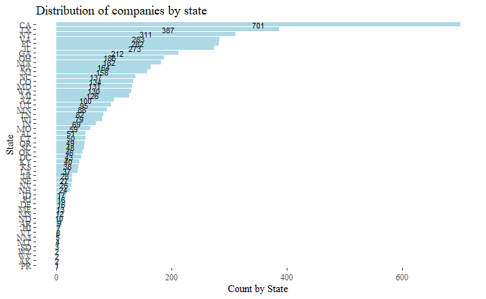

## Question 2

Lets dig in on the state with the 3rd most companies in the data set. Imagine you work for the state and are interested in how many people are employed by companies in different industries. Create a plot that shows the average and/or median employment by industry for companies in this state (only use cases with full data, use R’s `complete.cases()` function.) In addition to this, your graph should show how variable the ranges are, and you should deal with outliers.

## Answer 2 :

```r
# Subset only NY records
```

```
There were 34 warnings (use warnings() to see them)
```

```r
NyState <- inc[ which(inc$State == 'NY'), ]
# Remove incomplete records
NyState  <- NyState[complete.cases(NyState ), ]
# show data
head(NyState )
```

|  | Rank | Name | Growth_Rate | Revenue | Industry | Employees | City | State |
| --- | --- | --- | --- | --- | --- | --- | --- | --- |
| 26 | 26 | BeenVerified | 84.43 | 13700000 | Consumer Products & Services | 17 | New York | NY |
| 30 | 30 | Sailthru | 73.22 | 8100000 | Advertising & Marketing | 79 | New York | NY |
| 37 | 37 | YellowHammer | 67.40 | 18000000 | Advertising & Marketing | 27 | New York | NY |
| 38 | 38 | Conductor | 67.02 | 7100000 | Advertising & Marketing | 89 | New York | NY |
| 48 | 48 | Cinium Financial Services | 53.65 | 5900000 | Financial Services | 32 | Rock Hill | NY |
| 70 | 70 | 33Across | 44.99 | 27900000 | Advertising & Marketing | 75 | New York | NY |

```r
NA
```

## Question 3

Now imagine you work for an investor and want to see which industries generate the most revenue per employee. Create a chart that makes this information clear. Once again, the distribution per industry should be shown.

## Answer 3 :

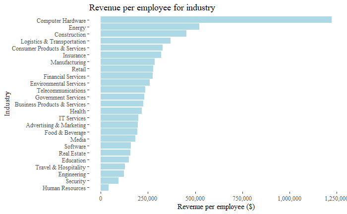